# Recruit Restaurant Visitor Forecasting

## 1.1 Business Problem

### Problem Statement:

Running a thriving local restaurant isn't always as charming as first impressions appear. There are often all sorts of unexpected troubles popping up that could hurt business. **One common predicament is that restaurants need to know how many customers to expect each day to effectively purchase ingredients and schedule staff members.** This forecast isn't easy to make because many unpredictable factors affect restaurant attendance, like weather and local competition. It's even harder for newer restaurants with little historical data. Recruit Holdings has unique access to key datasets that could make automated future customer prediction possible. Specifically, Recruit Holdings owns Hot Pepper Gourmet (a restaurant review service), AirREGI (a restaurant point of sales service), and Restaurant Board (reservation log management software). **In this competition, you're challenged to use reservation and visitation data to predict the total number of visitors to a restaurant for future dates. This information will help restaurants be much more efficient and allow them to focus on creating an enjoyable dining experience for their customers.**

### Loss function: RMSLE

RMSLE has this unique feature of penalizing underprediction compared to overprediction, which is important in this problem since we don't want the restaurants to be underprepared especially in case of small restaurants. Being over prepared has less effects on the business as the extra resources can be stored.

few other advantages:

```
* RMSLE is unaffected by the outlier values while RMSE does
* RMSLE focuses on the relational ratio difference between prediction and actual values while RMSE focuses on the difference between their magnitudes.
```

[read more](https://medium.com/analytics-vidhya/root-mean-square-log-error-rmse-vs-rmlse-935c6cc1802a)

## 1.2 Database

[figure not shown]

## 1.3 Data Description

1. **air_visit_data.csv**: This data contains the historical visits done to AIR registered restaurants
   - **air_store_id** : Unique ID for AIR registered restaurants
   - **visit_date** : The date of the day
   - **visitors** : No. of customers visited the restaurant
1. **air_reserve.csv**: This data contains the reservation done using AIR reservation system
   - **air_store_id** : Unique ID for AIR registered restaurants
   - **visit_datetime** : The visiting date done through reservation
   - **reserve_datetime** : The date on which reservation was made.
   - **reserve_visitors** : No. of visitors for the reservation
1. **air_store_data**: This data contains the location and restaurant type information for AIR
   - **air_store_id** : Unique ID for AIR registered restaurants
   - **air_genre_name** : Type of restaurant
   - **air_area_name** : area name of the restaurant
   - **latitude** : lat of the restaurant
   - **longitude** : long of the restaurant
1. **date_info.csv**: This data contains the visting day calendar information
   - **calendar_date** : The date
   - **day_of_week** : what day
   - **holiday_flg** : if the day was holiday? 1:yes; 0:No
1. **hpg_reserve.csv**: This data contains the reservations done through HPG reservation system
   - **hpg_store_id** : Unique ID for the restaurants in HPG database
   - **visit_datetime** : the time of the reservation
   - **reserve_datetime** : the time the reservation was made
   - **reserve_visitors** : the number of visitors for that reservation
1. **hpg_store_info.csv**: This data contains the location and restaurant type information for HPG
   - **hpg_store_id** : Unique ID for HPG registered restaurants
   - **hpg_genre_name** : Type of restaurant
   - **hpg_area_name** : area name of the restaurant
   - **latitude** : lat of the restaurant
   - **longitude** : long of the restaurant
1. **store_id_relation.csv**: This data contains the mapping for HPG restaurants ID to AIR restaurant ID
   - **hpg_store_id** : HPG unique ID
   - **air_store_id** : AIR unique ID
1. **sample_submission.csv**: This is test data for which the predictions has to be done.
   - **id** : The id is formed by concatenating the air_store_id and visit_date with an underscore
   - **visitors** : The number of visitors forecasted for the store and date combination

## 1.4 Data Preparation

```python
# imports
import pandas as pd
import numpy as np
import seaborn as sns
import matplotlib.pyplot as plt
import os

sns.set_style('whitegrid')

data_path = os.path.join(os.path.curdir, "Kaggle_Data")
processed_data_path = os.path.join(os.path.curdir, "Processed_Data")
```

```python
# read all the csv files

# air
air_visit_data = pd.read_csv(data_path + "/air_visit_data.csv", )
air_reservation_data = pd.read_csv(data_path + "/air_reserve.csv")
air_store_info = pd.read_csv(data_path + "/air_store_info.csv")

# date info
date_info = pd.read_csv(data_path + "/date_info.csv")

# hpg
hpg_reservation_data = pd.read_csv(data_path + "/hpg_reserve.csv")
hpg_store_info = pd.read_csv(data_path + "/hpg_store_info.csv")
store_id_relation = pd.read_csv(data_path + "/store_id_relation.csv")

# submission
submission = pd.read_csv(data_path + "/sample_submission.csv")
```

### 1.4.1: Null values checking

```python
def check_null_values(df: pd.DataFrame):
    """
    This function will check for null values in the dataframe
    """

    return np.any(df.isna().sum() > 1)


print("Null values check".center(50, "="))
print()
print("air_visit_data:", check_null_values(air_visit_data))
print("air_reservation_data:", check_null_values(air_reservation_data))
print("air_store_info:", check_null_values(air_store_info))
print("date_info:", check_null_values(date_info))
print("hpg_reservation_data:", check_null_values(hpg_reservation_data))
print("hpg_store_info:", check_null_values(hpg_store_info))
print("store_id_relation:", check_null_values(store_id_relation))
```

```
================Null values check=================

air_visit_data: False
air_reservation_data: False
air_store_info: False
date_info: False
hpg_reservation_data: False
hpg_store_info: False
store_id_relation: False
```

### 1.4.2 Data Merge

**air_visit_data.csv and date_info.csv**

```python
# rename the 'calendar_date' column to 'visit date'
date_info.rename(columns={'calendar_date': 'visit_date'}, inplace=True)

# merge the air_visit data and date info on 'visit date'
train_data = pd.merge(air_visit_data, date_info, how='left', on="visit_date")
train_data.sort_values(by='visit_date', inplace=True, ignore_index=True)

train_data.head()
```

|  | air_store_id | visit_date | visitors | day_of_week | holiday_flg |
| --- | --- | --- | --- | --- | --- |
| 0 | air_fab092c35776a9b1 | 2016-01-01 | 19 | Friday | 1 |
| 1 | air_f26f36ec4dc5adb0 | 2016-01-01 | 64 | Friday | 1 |
| 2 | air_d97dabf7aae60da5 | 2016-01-01 | 102 | Friday | 1 |
| 3 | air_39dccf7df20b1c6a | 2016-01-01 | 55 | Friday | 1 |
| 4 | air_79f528087f49df06 | 2016-01-01 | 42 | Friday | 1 |

**train_data.csv and air_store_info.csv**

```python
# merge the train data and air_store_info on 'air_store_id'
train_data = pd.merge(train_data, air_store_info, how='left', on="air_store_id")

train_data.head()
```

|  | air_store_id | visit_date | visitors | day_of_week | holiday_flg | air_genre_name | air_area_name | latitude | longitude |
| --- | --- | --- | --- | --- | --- | --- | --- | --- | --- |
| 0 | air_fab092c35776a9b1 | 2016-01-01 | 19 | Friday | 1 | Cafe/Sweets | Fukuoka-ken Fukuoka-shi Momochi | 33.581941 | 130.348436 |
| 1 | air_f26f36ec4dc5adb0 | 2016-01-01 | 64 | Friday | 1 | Izakaya | Tōkyō-to Shinjuku-ku Kabukichō | 35.693840 | 139.703549 |
| 2 | air_d97dabf7aae60da5 | 2016-01-01 | 102 | Friday | 1 | Cafe/Sweets | Tōkyō-to Shibuya-ku Jingūmae | 35.669290 | 139.707056 |
| 3 | air_39dccf7df20b1c6a | 2016-01-01 | 55 | Friday | 1 | Izakaya | Hyōgo-ken Takarazuka-shi Tōyōchō | 34.799767 | 135.360073 |
| 4 | air_79f528087f49df06 | 2016-01-01 | 42 | Friday | 1 | Western food | Tōkyō-to Suginami-ku Asagayaminami | 35.699566 | 139.636438 |

**train_data.csv and air_reservation_info.csv**

```python
# date time conversion
air_reservation_data.visit_datetime = pd.to_datetime(air_reservation_data.visit_datetime)
air_reservation_data.reserve_datetime = pd.to_datetime(air_reservation_data.reserve_datetime)

# add the hours gap difference between visit time to reservation time
air_reserve_diff = air_reservation_data.visit_datetime - air_reservation_data.reserve_datetime
air_reserve_diff = air_reserve_diff / np.timedelta64(1, 'h')
air_reservation_data['reservation_gap'] = air_reserve_diff

# add the visit date column
air_reservation_data['visit_date'] = air_reservation_data.visit_datetime.dt.date
```

```python
air_reservation_data.to_csv(processed_data_path + "/processed_air_reserve.csv", index=False)
air_reservation_data.head()
```

|  | air_store_id | visit_datetime | reserve_datetime | reserve_visitors | reservation_gap | visit_date |
| --- | --- | --- | --- | --- | --- | --- |
| 0 | air_877f79706adbfb06 | 2016-01-01 19:00:00 | 2016-01-01 16:00:00 | 1 | 3.0 | 2016-01-01 |
| 1 | air_db4b38ebe7a7ceff | 2016-01-01 19:00:00 | 2016-01-01 19:00:00 | 3 | 0.0 | 2016-01-01 |
| 2 | air_db4b38ebe7a7ceff | 2016-01-01 19:00:00 | 2016-01-01 19:00:00 | 6 | 0.0 | 2016-01-01 |
| 3 | air_877f79706adbfb06 | 2016-01-01 20:00:00 | 2016-01-01 16:00:00 | 2 | 4.0 | 2016-01-01 |
| 4 | air_db80363d35f10926 | 2016-01-01 20:00:00 | 2016-01-01 01:00:00 | 5 | 19.0 | 2016-01-01 |

```python
# we need to get total reservation visitors on the visit_date per restaurant
reservations_per_day = air_reservation_data.groupby(by=['air_store_id', 'visit_date'], as_index=False).sum()
reservations_per_day.visit_date = pd.to_datetime(reservations_per_day.visit_date)

# merge train_data and the total reservations done on the visit date per store id
train_data.visit_date = pd.to_datetime(train_data.visit_date)
train_data = pd.merge(train_data, reservations_per_day, how='left', on=['visit_date', 'air_store_id', ])
train_data.fillna(0, inplace=True)

# fill no reservation with zero
train_data.head()
```

|  | air_store_id | visit_date | visitors | day_of_week | holiday_flg | air_genre_name | air_area_name | latitude | longitude | reserve_visitors | reservation_gap |
| --- | --- | --- | --- | --- | --- | --- | --- | --- | --- | --- | --- |
| 0 | air_fab092c35776a9b1 | 2016-01-01 | 19 | Friday | 1 | Cafe/Sweets | Fukuoka-ken Fukuoka-shi Momochi | 33.581941 | 130.348436 | 0.0 | 0.0 |
| 1 | air_f26f36ec4dc5adb0 | 2016-01-01 | 64 | Friday | 1 | Izakaya | Tōkyō-to Shinjuku-ku Kabukichō | 35.693840 | 139.703549 | 0.0 | 0.0 |
| 2 | air_d97dabf7aae60da5 | 2016-01-01 | 102 | Friday | 1 | Cafe/Sweets | Tōkyō-to Shibuya-ku Jingūmae | 35.669290 | 139.707056 | 0.0 | 0.0 |
| 3 | air_39dccf7df20b1c6a | 2016-01-01 | 55 | Friday | 1 | Izakaya | Hyōgo-ken Takarazuka-shi Tōyōchō | 34.799767 | 135.360073 | 0.0 | 0.0 |
| 4 | air_79f528087f49df06 | 2016-01-01 | 42 | Friday | 1 | Western food | Tōkyō-to Suginami-ku Asagayaminami | 35.699566 | 139.636438 | 0.0 | 0.0 |

```python
train_data.to_csv(processed_data_path + "/processed_air_data.csv")
```

**train_data.csv and hpg_reservation.csv**

```python
## we need to extract the reservation made to the same AIR restaurants through HPG reservation system

# get the air_store_id's reservations done throught HPG reservation
hpg_database = pd.merge(hpg_reservation_data, store_id_relation, how='inner', on='hpg_store_id')

# add their store_information
hpg_database = pd.merge(hpg_database, hpg_store_info, how='left', on='hpg_store_id')

# add the reservation time diff
hpg_database.visit_datetime = pd.to_datetime(hpg_database.visit_datetime)
hpg_database.reserve_datetime = pd.to_datetime(hpg_database.reserve_datetime)
hpg_reserve_diff = hpg_database.visit_datetime - hpg_database.reserve_datetime
hpg_reserve_diff = hpg_reserve_diff / np.timedelta64(1, 'h')
hpg_database['hpg_reserve_gap'] = hpg_reserve_diff
hpg_database['hpg_visit_date'] = hpg_database.visit_datetime.dt.date
```

```python
hpg_database.to_csv(processed_data_path + "/processed_hpg_data.csv")
hpg_database.head()
```

|  | hpg_store_id | visit_datetime | reserve_datetime | reserve_visitors | air_store_id | hpg_genre_name | hpg_area_name | latitude | longitude | hpg_reserve_gap | hpg_visit_date |
| --- | --- | --- | --- | --- | --- | --- | --- | --- | --- | --- | --- |
| 0 | hpg_878cc70b1abc76f7 | 2016-01-01 19:00:00 | 2016-01-01 15:00:00 | 4 | air_db80363d35f10926 | Seafood | Hokkaidō Asahikawa-shi 3 Jōdōri | 43.768033 | 142.359664 | 4.0 | 2016-01-01 |
| 1 | hpg_878cc70b1abc76f7 | 2016-01-02 19:00:00 | 2016-01-02 14:00:00 | 2 | air_db80363d35f10926 | Seafood | Hokkaidō Asahikawa-shi 3 Jōdōri | 43.768033 | 142.359664 | 5.0 | 2016-01-02 |
| 2 | hpg_878cc70b1abc76f7 | 2016-01-03 18:00:00 | 2016-01-02 20:00:00 | 6 | air_db80363d35f10926 | Seafood | Hokkaidō Asahikawa-shi 3 Jōdōri | 43.768033 | 142.359664 | 22.0 | 2016-01-03 |
| 3 | hpg_878cc70b1abc76f7 | 2016-01-06 20:00:00 | 2016-01-04 22:00:00 | 3 | air_db80363d35f10926 | Seafood | Hokkaidō Asahikawa-shi 3 Jōdōri | 43.768033 | 142.359664 | 46.0 | 2016-01-06 |
| 4 | hpg_878cc70b1abc76f7 | 2016-01-11 18:00:00 | 2016-01-11 14:00:00 | 2 | air_db80363d35f10926 | Seafood | Hokkaidō Asahikawa-shi 3 Jōdōri | 43.768033 | 142.359664 | 4.0 | 2016-01-11 |

```python
# we need to get total reservation visitors on the visit_date per restaurant
hpg_reservations_per_day = hpg_database.groupby(by=['air_store_id', 'hpg_visit_date'], as_index=False)[['reserve_visitors', 'hpg_reserve_gap']].sum()
hpg_reservations_per_day.rename(columns={'hpg_visit_date': 'visit_date'}, inplace=True)
hpg_reservations_per_day.visit_date = pd.to_datetime(hpg_reservations_per_day.visit_date)

# merge train_data and the total reservations done on the visit date per store id
train_data = pd.merge(train_data, hpg_reservations_per_day, how='left', on=['visit_date', 'air_store_id'], suffixes=("_air", "_hpg"))
train_data.fillna(0, inplace=True)

# fill no reservation with zero
train_data.head()
```

|  | air_store_id | visit_date | visitors | day_of_week | holiday_flg | air_genre_name | air_area_name | latitude | longitude | reserve_visitors_air | reservation_gap | reserve_visitors_hpg | hpg_reserve_gap |
| --- | --- | --- | --- | --- | --- | --- | --- | --- | --- | --- | --- | --- | --- |
| 0 | air_fab092c35776a9b1 | 2016-01-01 | 19 | Friday | 1 | Cafe/Sweets | Fukuoka-ken Fukuoka-shi Momochi | 33.581941 | 130.348436 | 0.0 | 0.0 | 0.0 | 0.0 |
| 1 | air_f26f36ec4dc5adb0 | 2016-01-01 | 64 | Friday | 1 | Izakaya | Tōkyō-to Shinjuku-ku Kabukichō | 35.693840 | 139.703549 | 0.0 | 0.0 | 0.0 | 0.0 |
| 2 | air_d97dabf7aae60da5 | 2016-01-01 | 102 | Friday | 1 | Cafe/Sweets | Tōkyō-to Shibuya-ku Jingūmae | 35.669290 | 139.707056 | 0.0 | 0.0 | 0.0 | 0.0 |
| 3 | air_39dccf7df20b1c6a | 2016-01-01 | 55 | Friday | 1 | Izakaya | Hyōgo-ken Takarazuka-shi Tōyōchō | 34.799767 | 135.360073 | 0.0 | 0.0 | 0.0 | 0.0 |
| 4 | air_79f528087f49df06 | 2016-01-01 | 42 | Friday | 1 | Western food | Tōkyō-to Suginami-ku Asagayaminami | 35.699566 | 139.636438 | 0.0 | 0.0 | 0.0 | 0.0 |

```python
train_data.to_csv(processed_data_path + "/processed_train_data.csv", index=False)
```

**submission.csv**

```python
submission['air_store_id'] = submission.id.str[:20]
submission['visit_date'] = submission.id.str[21:]
submission.head()
```

|  | id | visitors | air_store_id | visit_date |
| --- | --- | --- | --- | --- |
| 0 | air_00a91d42b08b08d9_2017-04-23 | 0 | air_00a91d42b08b08d9 | 2017-04-23 |
| 1 | air_00a91d42b08b08d9_2017-04-24 | 0 | air_00a91d42b08b08d9 | 2017-04-24 |
| 2 | air_00a91d42b08b08d9_2017-04-25 | 0 | air_00a91d42b08b08d9 | 2017-04-25 |
| 3 | air_00a91d42b08b08d9_2017-04-26 | 0 | air_00a91d42b08b08d9 | 2017-04-26 |
| 4 | air_00a91d42b08b08d9_2017-04-27 | 0 | air_00a91d42b08b08d9 | 2017-04-27 |

```python
submission.to_csv(processed_data_path + "/processed_test_data.csv", index=False)
```

```python
print()
print("Train Data information".center(50, "="))
print()
print("Train dataset size: ", train_data.shape)
print("Total unique restaurants", len(train_data.air_store_id.unique()))
print("Total unique restaurant genre: ", len(train_data.air_genre_name.unique()))
print(f"Average visitors: {train_data.visitors.mean():.2f}")
print(f"Median visitors: {train_data.visitors.median():.2f}")
print("The average/median vistors for restaurants is around 18-20. Most of these restaurants are small")
print("No of days data:", len(train_data.visit_date.unique()))
print(f"Date span: {train_data.visit_date.min().date()} - {train_data.visit_date.max().date()}")

print()
print("Test Data information".center(50, "="))
print()
print("Total unique restarants: ", len(submission.air_store_id.unique()))
print("No of days to be predicted: ",len(submission.visit_date.unique()))
submission.visit_date = pd.to_datetime(submission.visit_date)
print(f"Date span: {submission.visit_date.min().date()} - {submission.visit_date.max().date()}")
```

```
==============Train Data information==============

Train dataset size:  (252108, 13)
Total unique restaurants 829
Total unique restaurant genre:  14
Average visitors: 20.97
Median visitors: 17.00
The average/median vistors for restaurants is around 18-20. Most of these restaurants are small
No of days data: 478
Date span: 2016-01-01 - 2017-04-22

==============Test Data information===============

Total unique restarants:  821
No of days to be predicted:  39
Date span: 2017-04-23 - 2017-05-31
```

## 1.5 EDA

```python
import matplotlib.pyplot as plt
import seaborn as sns
import pandas as pd
import datetime
sns.set_style('darkgrid')

%matplotlib inline
```

```python
train_data = pd.read_csv(processed_data_path + "/processed_train_data.csv")
submission = pd.read_csv(processed_data_path + "/processed_test_data.csv")
train_data.visit_date = pd.to_datetime(train_data.visit_date)
train_data.head()
```

|  | air_store_id | visit_date | visitors | day_of_week | holiday_flg | air_genre_name | air_area_name | latitude | longitude | reserve_visitors_air | reservation_gap | reserve_visitors_hpg | hpg_reserve_gap |
| --- | --- | --- | --- | --- | --- | --- | --- | --- | --- | --- | --- | --- | --- |
| 0 | air_fab092c35776a9b1 | 2016-01-01 | 19 | Friday | 1 | Cafe/Sweets | Fukuoka-ken Fukuoka-shi Momochi | 33.581941 | 130.348436 | 0.0 | 0.0 | 0.0 | 0.0 |
| 1 | air_f26f36ec4dc5adb0 | 2016-01-01 | 64 | Friday | 1 | Izakaya | Tōkyō-to Shinjuku-ku Kabukichō | 35.693840 | 139.703549 | 0.0 | 0.0 | 0.0 | 0.0 |
| 2 | air_d97dabf7aae60da5 | 2016-01-01 | 102 | Friday | 1 | Cafe/Sweets | Tōkyō-to Shibuya-ku Jingūmae | 35.669290 | 139.707056 | 0.0 | 0.0 | 0.0 | 0.0 |
| 3 | air_39dccf7df20b1c6a | 2016-01-01 | 55 | Friday | 1 | Izakaya | Hyōgo-ken Takarazuka-shi Tōyōchō | 34.799767 | 135.360073 | 0.0 | 0.0 | 0.0 | 0.0 |
| 4 | air_79f528087f49df06 | 2016-01-01 | 42 | Friday | 1 | Western food | Tōkyō-to Suginami-ku Asagayaminami | 35.699566 | 139.636438 | 0.0 | 0.0 | 0.0 | 0.0 |

#### Visitors trend across the days

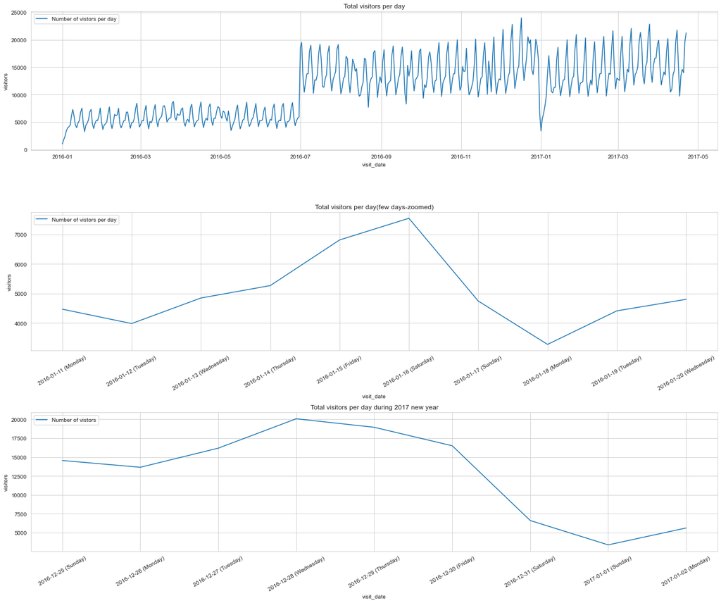

```python
# per day visitors
fig = plt.figure(figsize=(18,15))

ax1 = fig.add_subplot(311)

temp = train_data.groupby("visit_date").visitors.sum()

sns.lineplot(temp.index, temp, ax=ax1, label="Number of vistors per day")
plt.title("Total visitors per day")
plt.legend(loc='upper left')


ax2 = fig.add_subplot(312)
sns.lineplot(temp.index[10:20], temp[10:20], ax=ax2, label="Number of vistors per day")
ax2.set_xticklabels(temp[10:20].index.strftime("%Y-%m-%d (%A)"), rotation=30)
plt.legend(loc='upper left')
plt.title("Total visitors per day(few days-zoomed)")


temp = temp.loc['2016-12-25': '2017-01-02']

ax3 = fig.add_subplot(313)
sns.lineplot(temp.index, temp, ax=ax3, label="Number of vistors")
ax3.set_xticklabels(temp.index.strftime("%Y-%m-%d (%A)"), rotation=30)
plt.title("Total visitors per day during 2017 new year")
plt.legend(loc='upper left')
plt.tight_layout()
plt.show()
```

- `It can be observed that there is seasonality for visitors variable. Around July 2016, there is a sharp rise is in visitors, this could be due to more restaurants being added to the database.`
- `The seasonality across training data is corresponding to the weekly cycle. As the weekend nears, there is rise in visitors for AIR restaurants.`
- `There is also sharp dip in visitors during 2017-01-01, which is due to New year celebration.`

#### Visitors trend during golden week

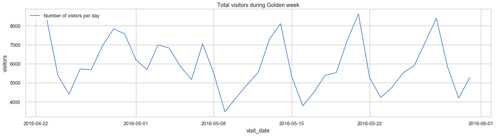

```python
# per day visitors
fig = plt.figure(figsize=(18,5))

ax1 = fig.add_subplot(111)

temp = train_data.groupby("visit_date").visitors.sum()

# the golden week is between april and may
temp = temp.loc['2016-04-23': '2016-05-31']

sns.lineplot(temp.index, temp, ax=ax1, label="Number of vistors per day")
plt.title("Total visitors during Golden week")
plt.legend(loc='upper left')
plt.tight_layout()
plt.show()
```

- `The golden week(April 29 - May 05) effect can be seen on visitors. There is consistency in visitors for AIR restaurants.`
- `After the golden week(May 06), there is dip in visitors, even on the weekend. The next week the weekly trend continues.`
- `Since the test data set spans around the golden week, this exception needs to be handled.`

```python
train_data.head()
```

|  | air_store_id | visit_date | visitors | day_of_week | holiday_flg | air_genre_name | air_area_name | latitude | longitude | reserve_visitors_air | reservation_gap | reserve_visitors_hpg | hpg_reserve_gap |
| --- | --- | --- | --- | --- | --- | --- | --- | --- | --- | --- | --- | --- | --- |
| 0 | air_fab092c35776a9b1 | 2016-01-01 | 19 | Friday | 1 | Cafe/Sweets | Fukuoka-ken Fukuoka-shi Momochi | 33.581941 | 130.348436 | 0.0 | 0.0 | 0.0 | 0.0 |
| 1 | air_f26f36ec4dc5adb0 | 2016-01-01 | 64 | Friday | 1 | Izakaya | Tōkyō-to Shinjuku-ku Kabukichō | 35.693840 | 139.703549 | 0.0 | 0.0 | 0.0 | 0.0 |
| 2 | air_d97dabf7aae60da5 | 2016-01-01 | 102 | Friday | 1 | Cafe/Sweets | Tōkyō-to Shibuya-ku Jingūmae | 35.669290 | 139.707056 | 0.0 | 0.0 | 0.0 | 0.0 |
| 3 | air_39dccf7df20b1c6a | 2016-01-01 | 55 | Friday | 1 | Izakaya | Hyōgo-ken Takarazuka-shi Tōyōchō | 34.799767 | 135.360073 | 0.0 | 0.0 | 0.0 | 0.0 |
| 4 | air_79f528087f49df06 | 2016-01-01 | 42 | Friday | 1 | Western food | Tōkyō-to Suginami-ku Asagayaminami | 35.699566 | 139.636438 | 0.0 | 0.0 | 0.0 | 0.0 |

#### Average visitors by week/month for the year 2016-17

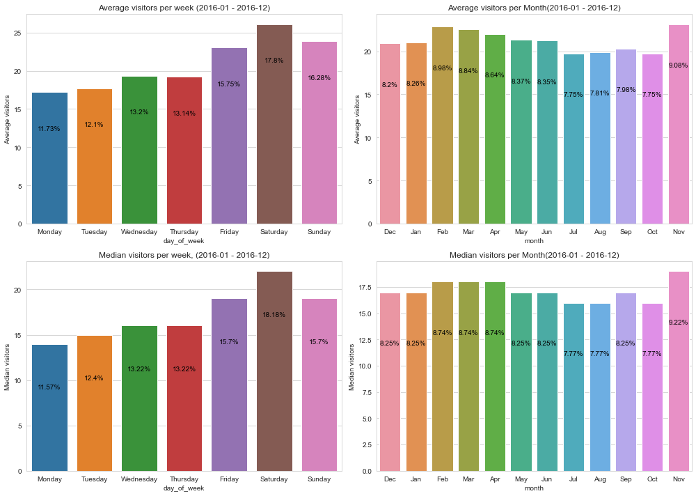

```python
# average per week, per month
fig = plt.figure(figsize=(14,10))

ax1 = fig.add_subplot(221)
# order the days
# https://stackoverflow.com/a/35194104/9103175
train_data.day_of_week = pd.Categorical(train_data['day_of_week'], categories=
    ['Monday', 'Tuesday', 'Wednesday', 'Thursday', 'Friday', 'Saturday', 'Sunday'],
    ordered=True)

train_2016_data = train_data.loc[train_data.visit_date.dt.year == 2016]

temp = train_2016_data.groupby("day_of_week", as_index=False).visitors.mean()
temp = temp.sort_index()
temp['percent'] =  (temp.visitors / temp.visitors.sum()) * 100

g = sns.barplot(temp.day_of_week, temp.visitors, ax=ax1)

for index, row in temp.iterrows():
    g.text(index, row.visitors-5, str(np.round(row.percent,2)) + "%", color='black', ha="center")

plt.title("Average visitors per week (2016-01 - 2016-12)")
plt.ylabel("Average visitors")

train_2016_data.loc[:, 'month'] = train_2016_data.loc[:, 'visit_date'].dt.month
temp = train_2016_data.groupby("month", as_index=False).visitors.mean()
temp['percent'] =  (temp.visitors / temp.visitors.sum()) * 100

ax2 = fig.add_subplot(222)
g = sns.barplot(temp.month, temp.visitors, ax=ax2)
months = ['Jan', 'Feb', 'Mar', 'Apr', 'May', 'Jun', 'Jul', 'Aug', 'Sep', 'Oct', 'Nov', 'Dec']

for index, row in temp.iterrows():
    g.text(index, row.visitors-5, str(np.round(row.percent,2)) + "%", color='black', ha="center")

    plt.title("Average visitors per Month(2016-01 - 2016-12)")
x_labels = [ months[i-1] for i in temp.index]
ax2.set_xticklabels(x_labels)
plt.ylabel("Average visitors")


# Median per week, per month
ax3 = fig.add_subplot(223)
temp = train_2016_data.groupby("day_of_week", as_index=False).visitors.median()
temp = temp.sort_index()
temp['percent'] =  (temp.visitors / temp.visitors.sum()) * 100

g = sns.barplot(temp.day_of_week, temp.visitors, ax=ax3)

for index, row in temp.iterrows():
    g.text(index, row.visitors-5, str(np.round(row.percent,2)) + "%", color='black', ha="center")

plt.title("Median visitors per week, (2016-01 - 2016-12)")
plt.ylabel("Median visitors")

train_2016_data.loc[:, 'month'] = train_2016_data.loc[:, 'visit_date'].dt.month
temp = train_2016_data.groupby("month", as_index=False).visitors.median()
temp['percent'] =  (temp.visitors / temp.visitors.sum()) * 100

ax4 = fig.add_subplot(224)
g = sns.barplot(temp.month, temp.visitors, ax=ax4)

for index, row in temp.iterrows():
    g.text(index, row.visitors-5, str(np.round(row.percent,2)) + "%", color='black', ha="center")

months = ['Jan', 'Feb', 'Mar', 'Apr', 'May', 'Jun', 'Jul', 'Aug', 'Sep', 'Oct', 'Nov', 'Dec']
plt.title("Median visitors per Month(2016-01 - 2016-12)")
x_labels = [ months[i-1] for i in temp.index]
ax4.set_xticklabels(x_labels)
plt.ylabel("Median visitors")
plt.tight_layout()
plt.show()
```

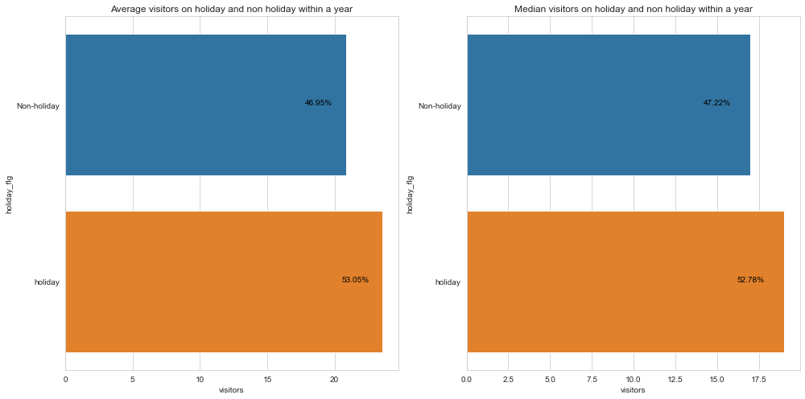

```python
# average vistors on holiday and non holiday
fig = plt.figure(figsize=(14,7))

ax1 = fig.add_subplot(121)

temp = train_2016_data.groupby("holiday_flg", as_index=False).visitors.mean()
temp['percent'] = (temp.visitors / temp.visitors.sum()) * 100

g = sns.barplot(temp.visitors, temp.holiday_flg, ax=ax1, orient='h')

for index, row in temp.iterrows():
    g.text(row.visitors-2, index, str(np.round(row.percent, 2)) + "%", color='black', ha="center")
labels = ['Non-holiday', 'holiday']
ax1.set_yticklabels([labels[i] for i in temp.index])
plt.title("Average visitors on holiday and non holiday within a year")

temp = train_2016_data.groupby("holiday_flg", as_index=False).visitors.median()
temp['percent'] = (temp.visitors / temp.visitors.sum()) * 100
ax2 = fig.add_subplot(122)
g = sns.barplot(temp.visitors, temp.holiday_flg, ax=ax2, orient='h')
for index, row in temp.iterrows():
    g.text(row.visitors-2, index, str(np.round(row.percent, 2)) + "%", color='black', ha="center")

labels = ['Non-holiday', 'holiday']
ax2.set_yticklabels([labels[i] for i in temp.index])
plt.title("Median visitors on holiday and non holiday within a year")

plt.tight_layout()
plt.show()
```

- `For obvious reasons, the visitors are high on holidays in comparison to visitors on non-holiday`

#### Visitors trend on weekends vs weekdays

```python
# weekend_flag
train_data['weekend_flag'] = train_data.day_of_week.isin(['Saturday','Sunday']).astype(int)
train_data.head(2)
```

|  | air_store_id | visit_date | visitors | day_of_week | holiday_flg | air_genre_name | air_area_name | latitude | longitude | reserve_visitors_air | reservation_gap | reserve_visitors_hpg | hpg_reserve_gap | weekend_flag |
| --- | --- | --- | --- | --- | --- | --- | --- | --- | --- | --- | --- | --- | --- | --- |
| 0 | air_fab092c35776a9b1 | 2016-01-01 | 19 | Friday | 1 | Cafe/Sweets | Fukuoka-ken Fukuoka-shi Momochi | 33.581941 | 130.348436 | 0.0 | 0.0 | 0.0 | 0.0 | 0 |
| 1 | air_f26f36ec4dc5adb0 | 2016-01-01 | 64 | Friday | 1 | Izakaya | Tōkyō-to Shinjuku-ku Kabukichō | 35.693840 | 139.703549 | 0.0 | 0.0 | 0.0 | 0.0 | 0 |

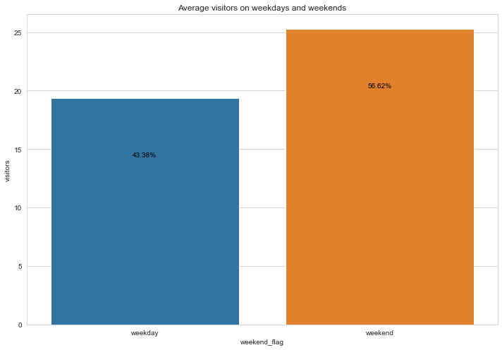

```python
# average vistors on weekend and weekdays
fig = plt.figure(figsize=(10,7))

ax1 = fig.add_subplot(111)

temp = train_data.groupby("weekend_flag", as_index=False).visitors.mean()
temp['percent'] = (temp.visitors / temp.visitors.sum()) * 100
g = sns.barplot(temp.weekend_flag, temp.visitors, ax=ax1)

for index, row in temp.iterrows():
    g.text(index, row.visitors-5, str(np.round(row.percent, 2)) + "%", color='black', ha='center')

labels = ['weekday', 'weekend']
ax1.set_xticklabels([labels[i] for i in temp.index])
plt.title("Average visitors on weekdays and weekends")

plt.tight_layout()
plt.show()
```

- `weekends have more visitors in comparison to weekdays`

#### Visitors trend if next day is holiday

```python
# next_day_holiday_flag
train_data['nxt_day_holiday_flg'] = train_data.day_of_week.isin(['Friday','Saturday']).astype(int)
train_data.head(2)
```

|  | air_store_id | visit_date | visitors | day_of_week | holiday_flg | air_genre_name | air_area_name | latitude | longitude | reserve_visitors_air | reservation_gap | reserve_visitors_hpg | hpg_reserve_gap | weekend_flag | nxt_day_holiday_flg |
| --- | --- | --- | --- | --- | --- | --- | --- | --- | --- | --- | --- | --- | --- | --- | --- |
| 0 | air_fab092c35776a9b1 | 2016-01-01 | 19 | Friday | 1 | Cafe/Sweets | Fukuoka-ken Fukuoka-shi Momochi | 33.581941 | 130.348436 | 0.0 | 0.0 | 0.0 | 0.0 | 0 | 1 |
| 1 | air_f26f36ec4dc5adb0 | 2016-01-01 | 64 | Friday | 1 | Izakaya | Tōkyō-to Shinjuku-ku Kabukichō | 35.693840 | 139.703549 | 0.0 | 0.0 | 0.0 | 0.0 | 0 | 1 |

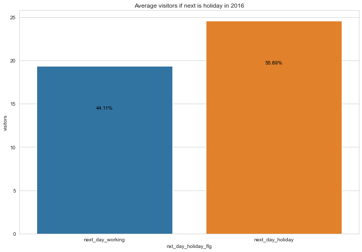

```python
# average vistors if next day is holiday
fig = plt.figure(figsize=(10,7))

ax1 = fig.add_subplot(111)

train_2016_data = train_data.loc[train_data.visit_date.dt.year == 2016]

temp = train_2016_data.groupby("nxt_day_holiday_flg", as_index=False).visitors.mean()
temp['percent'] = (temp.visitors / temp.visitors.sum()) * 100

g = sns.barplot(temp.nxt_day_holiday_flg, temp.visitors, ax=ax1)
for index, row in temp.iterrows():
    g.text(index, row.visitors-5, str(np.round(row.percent, 2)) + "%", color='black', ha='center')

labels = ['next_day_working', 'next_day_holiday']
ax1.set_xticklabels([labels[i] for i in temp.index])
plt.title("Average visitors if next is holiday in 2016")

plt.tight_layout()
plt.show()
```

- `Visitors are high not only during holidays, but also if next day is holiday`

#### reservations done through AIR/HPG system

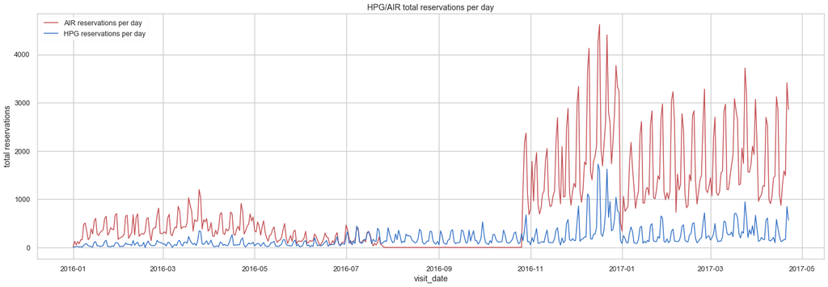

```python
# reservations
# total reservations per day
temp = train_data.groupby("visit_date").reserve_visitors_air.sum()
temp2 = train_data.groupby("visit_date").reserve_visitors_hpg.sum()

fig = plt.figure(figsize=(25,8))

ax = fig.add_subplot(111)

sns.lineplot(temp.index, temp, label="AIR reservations per day", color='r', ax=ax)
sns.lineplot(temp2.index, temp2, label="HPG reservations per day", color='b', ax=ax)
plt.legend(loc='upper left')
plt.ylabel("total reservations")

plt.title("HPG/AIR total reservations per day")
plt.show()
```

- `AIR reservations have missing data between 2016-07 to 2016-11`
- `Both reservations are high during the December and drop on the 2017-01-01`
- `The reservations in both systems seems to be more in 2017 especially in AIR system compared to 2016`

#### Does reservations has any effect on visitors?

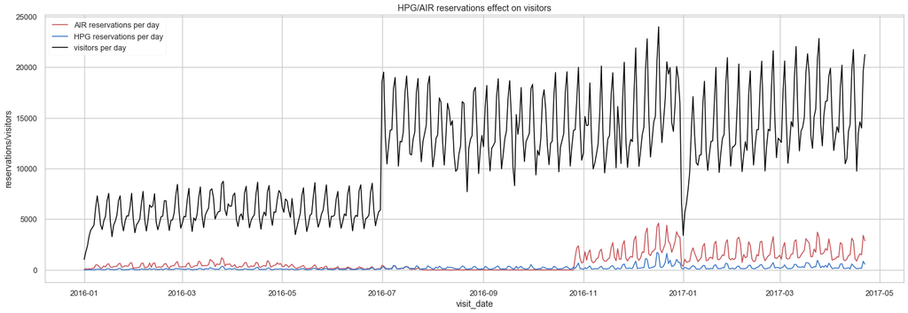

```python
# reservations
# total reservations per day
temp = train_data.groupby("visit_date").reserve_visitors_air.sum()
temp2 = train_data.groupby("visit_date").reserve_visitors_hpg.sum()
temp3 = train_data.groupby("visit_date").visitors.sum()

fig = plt.figure(figsize=(25,8))

ax = fig.add_subplot(111)

sns.lineplot(temp.index, temp, label="AIR reservations per day", color='r', ax=ax)
sns.lineplot(temp2.index, temp2, label="HPG reservations per day", color='b', ax=ax)
sns.lineplot(temp3.index, temp3, label="visitors per day", color='black', ax=ax)
plt.legend(loc='upper left')
plt.ylabel("reservations/visitors")

plt.title("HPG/AIR reservations effect on visitors")
plt.show()
```

- `The reservations do have positive effect on visitors. Around 2016-11, it can be observed that visitors are spiking with reservations`
- `This observation can also mean that most of the reservations are done for single day`
- `Also visitor number is higher in comparison with reservations. This is obvious as most prefer to walk in than reservations. Also the reservations are higher in December. This is due to busy restaurants on new years eve and its better to reserve than walking in`

#### Reservation time

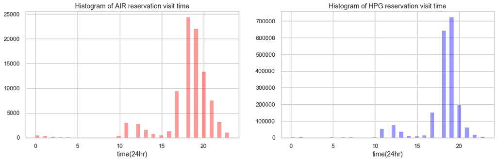

```python
air_reservation_data.visit_datetime = pd.to_datetime(air_reservation_data.visit_datetime)
air_reservation_data.reserve_datetime = pd.to_datetime(air_reservation_data.reserve_datetime)

fig = plt.figure(figsize=(18, 5))
ax1 = fig.add_subplot(121)

sns.distplot(air_reservation_data.visit_datetime.dt.hour, color='red', kde=False, ax=ax1)
plt.title("Histogram of AIR reservation visit time")
plt.xlabel("time(24hr)")

ax2 = fig.add_subplot(122)
hpg_reservation_data.visit_datetime = pd.to_datetime(hpg_reservation_data.visit_datetime)
hpg_reservation_data.reserve_datetime = pd.to_datetime(hpg_reservation_data.reserve_datetime)
sns.distplot(hpg_reservation_data.visit_datetime.dt.hour, color='blue', kde=False, ax=ax2)
plt.title("Histogram of HPG reservation visit time")
plt.xlabel("time(24hr)")
plt.show()

plt.show()
```

- `Both in AIR and HPG, reservations are high for dinner time`
- `reservations on HPG system are lot higher in comparison with AIR`

#### Which genre is popular among visitors?

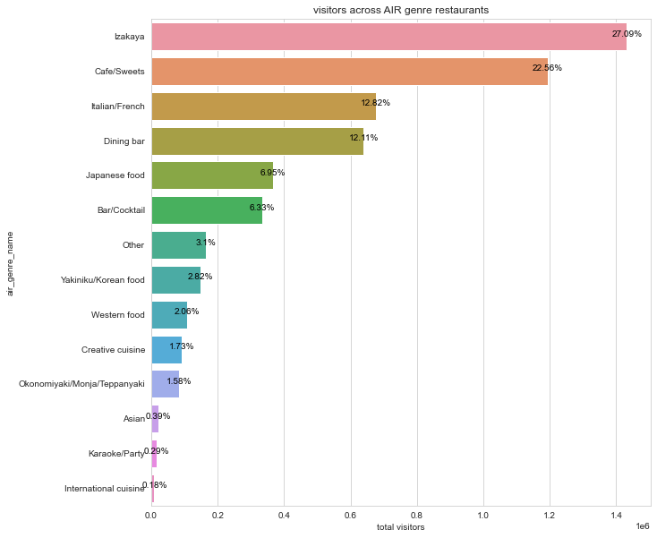

```python
fig, ax = plt.subplots(figsize=(10,10))

temp = train_data.groupby("air_genre_name", as_index=False).visitors.sum()
temp.sort_values(by='visitors', inplace=True, ascending=False)
temp = temp.reset_index()
temp['percent'] = (temp.visitors / temp.visitors.sum()) * 100

g = sns.barplot(x=temp.visitors, y=temp.air_genre_name, ax=ax)
for index, row in temp.iterrows():
    g.text(row.visitors - 7, index, str(np.round(row.percent, 2)) + '%', ha='center', color='black')
plt.title("visitors across AIR genre restaurants")
plt.xlabel("total visitors")
plt.show()
```

- `'IZAKAYA' seem genre is popular among visitors. A google search reveals that 'IZAKAYA' are japanese bars which serve alcohol and snacks and is common choice for after work drinking`
- `after work or morning cafes/sweets has second highest visitors`
- `Though reservation is highest for Dinner time, the visitor count for food restaurants is less`
- `International cuisine has the least visitors`

#### area wise, genre wise restaurant count

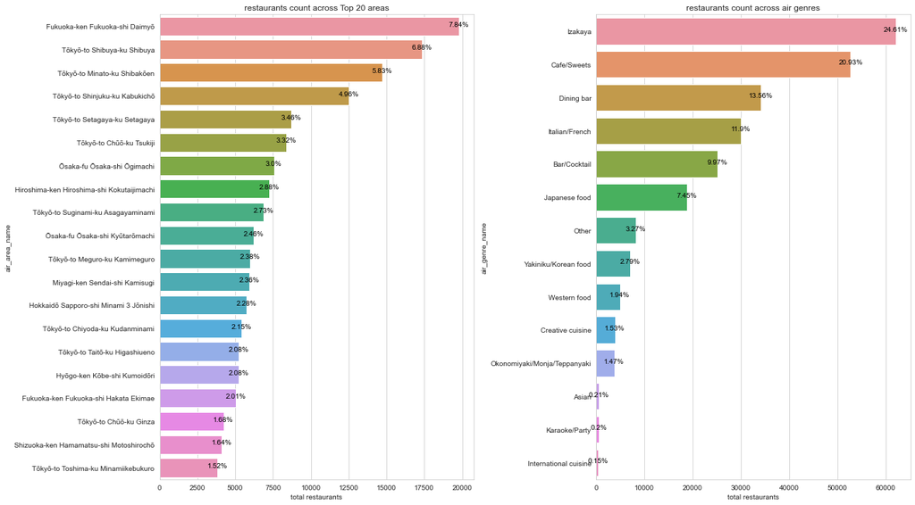

```python
fig = plt.figure(figsize=(18,10))

# top 20
temp = train_data.groupby("air_area_name", as_index=False).air_store_id.count()
temp.sort_values(by='air_store_id', inplace=True, ascending=False)
temp.reset_index(inplace=True)
temp['percent'] = (temp.air_store_id / temp.air_store_id.sum()) * 100

ax1 = fig.add_subplot(121)
g = sns.barplot(x=temp[:20].air_store_id, y=temp.air_area_name[:20], ax=ax1)
for index, row in temp[:20].iterrows():
    g.text(row.air_store_id - 7, index, str(np.round(row.percent, 2)) + '%', ha='center', color='black')
plt.title("restaurants count across Top 20 areas")
plt.xlabel("total restaurants")

temp = train_data.groupby("air_genre_name", as_index=False).air_store_id.count()
temp.sort_values(by='air_store_id', inplace=True, ascending=False)
temp.reset_index(inplace=True)
temp['percent'] = (temp.air_store_id / temp.air_store_id.sum()) * 100

ax2 = fig.add_subplot(122)
g = sns.barplot(x=temp.air_store_id, y=temp.air_genre_name, ax=ax2)

for index, row in temp[:20].iterrows():
    g.text(row.air_store_id - 7, index, str(np.round(row.percent, 2)) + '%', ha='center', color='black')

plt.title("restaurants count across air genres")
plt.xlabel("total restaurants")

plt.tight_layout()
plt.show()
```

- `Fukouka has the most restaurants followed by many areas around tokyo`
- `Izakaya, Cafe/sweets types of restaurants are high in numbers. No wonder the visitors count are high among these types`

#### Diff genre restaurants area wise

```python
temp = train_data.groupby(['air_area_name', 'air_genre_name'], as_index=True).air_store_id.count()
temp = temp.unstack(fill_value=0)
# temp = (temp.T / temp.T.sum()).T
temp.head()
```

| air_genre_name air_area_name | Asian | Bar/Cocktail | Cafe/Sweets | Creative cuisine | Dining bar | International cuisine | Italian/French | Izakaya | Japanese food | Karaoke/Party | Okonomiyaki/Monja/Teppanyaki | Other | Western food | Yakiniku/Korean food |
| --- | --- | --- | --- | --- | --- | --- | --- | --- | --- | --- | --- | --- | --- | --- |
| Fukuoka-ken Fukuoka-shi Daimyō | 0 | 2594 | 7421 | 648 | 1861 | 0 | 2870 | 2037 | 808 | 0 | 0 | 735 | 0 | 801 |
| Fukuoka-ken Fukuoka-shi Hakata Ekimae | 0 | 574 | 0 | 0 | 0 | 0 | 844 | 2591 | 422 | 0 | 0 | 628 | 0 | 0 |
| Fukuoka-ken Fukuoka-shi Imaizumi | 0 | 0 | 0 | 0 | 0 | 0 | 0 | 480 | 0 | 0 | 0 | 0 | 0 | 0 |
| Fukuoka-ken Fukuoka-shi Momochi | 0 | 0 | 1477 | 0 | 0 | 0 | 0 | 0 | 538 | 0 | 0 | 0 | 0 | 0 |
| Fukuoka-ken Fukuoka-shi Shiobaru | 0 | 0 | 1097 | 0 | 0 | 0 | 0 | 1082 | 0 | 0 | 0 | 0 | 0 | 0 |

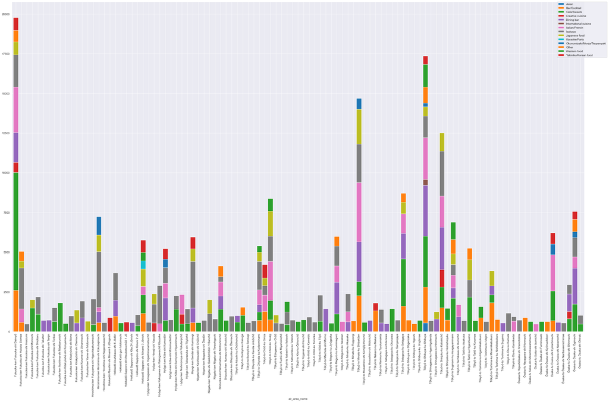

```python
temp.plot(kind='bar', stacked=True, figsize=(30, 20), width=0.9)
# https://stackoverflow.com/a/43439132/9103175
plt.legend(bbox_to_anchor=(1.04,1), borderaxespad=0)
plt.tight_layout()
plt.show()
```

#### area wise restaurant cluster

```python
import folium
from folium.plugins import MarkerCluster

japan_map = folium.Map(location=[36.2048, 138.2529], tiles="CartoDBpositron", zoom_start=6, min_zoom=4)
marker_cluster = MarkerCluster().add_to(japan_map)

for row in air_store_info.values:

    folium.Marker(location=[row[-2], row[-1]], popup=f"{row[0]} - {row[1]} - {row[2]}").add_to(marker_cluster)

japan_map
```

Make this Notebook Trusted to load map: File -> Trust Notebook

[interactive chart not shown]

- `From the map, the Fukuoka has highest restaurants around one single place. Hence the high number of visitors.`
- `while the Tokyo area has overall high number of restaurants, they form different clusters spread in different areas of Tokyo. Hence the visitors are spread out.`
- `Area name could be very important information is determining the visitors.`
- `Osaka is second most popular and reasturants are spread out`
- `Also we can see that more the restaurants in the area more the visitors count. Area wise resturant count could be useful`

```python
japan_map.save("japan.html")
```

#### visitors trend across genre

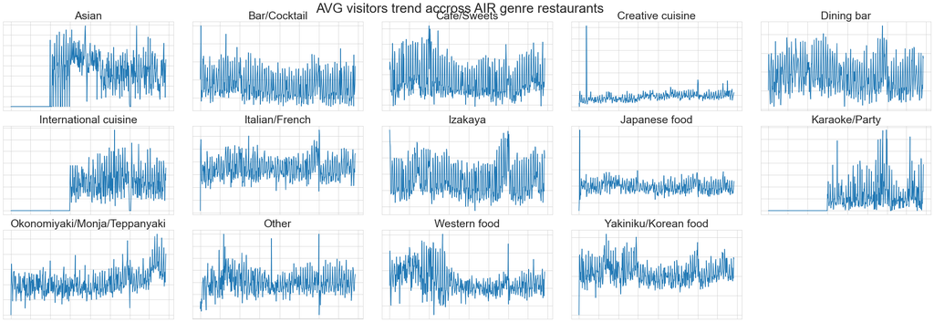

```python
temp = train_data.groupby(["visit_date", 'air_genre_name']).visitors.mean()
temp = temp.unstack(-1, fill_value=0)

fig = plt.figure(figsize=(30,10))

columns = temp.columns
for index, genre in enumerate(columns):

    ax = fig.add_subplot(3,5, index+1)
    sns.lineplot(temp.index, temp[genre], ax=ax)
    ax.set_xticklabels(labels=[])
    ax.set_yticklabels(labels=[])
    ax.set_title(genre, fontsize=25)
    plt.xlabel("")
    plt.ylabel("")

fig.suptitle("AVG visitors trend accross AIR genre restaurants", fontsize=30, ha='center', va='baseline')
plt.tight_layout()
plt.show()
```

- `Most genre have consistent visitors. Some of them, 'Karoke/Party', 'International Cuisine' have no visits data upto certain date`
- `Korean Food, Western Food, Asian have variable visits`
- `Japanese food seems to have the most consistent visits`

#### Conclusion

- Visitors variable data is periodic in nature corresponding to a week pattern where there is a rise in visitors on weekends.
- The visit database has spike in data during July 2016, which might be the effect of additional restaurants being added to database.
- The Golden Week Season data can be seen in visitors variable, where the visitors have been consistent. This occurs during April 29 2016 to May 05 2016.
- We also see sharp dip in visitors on 2017-01-01. This might be due to most restaurants are closed on Jan 1st.
- On weekly basis, Visitors are high on Saturday and equally on Friday and Sunday.
- Month wise, December has more visitors compared to rest owing to festivals and New year's Eve.
- For obvious reasons, the visitors are high if its a public holiday.
- Restaurants see a rise in visitors if the next day is holiday, compared to next day working. This trend is also seen on weekly basis where Friday has more visitors compared to other working days, since Saturday is weekend.
- The reservations has similar trend to visitors. However, many prefer to walk in. This is evident from the huge difference between reservations and visitors.
- The AIR reservation system has missing data between 2016-07 to 2016-11. No explanation is given for this missing data.
- Both in AIR and HPG reservation system, the reservations are less before 2016-11, but there is sudden rise in reservations after this.
- Majority of the reservations are done for dinner time.
- Bars and snacks genre, also known as 'Izakaya' in Japan is most popular among customers. Also this is highly spread across locations.
- Next to Izakaya, Cafe/Sweets seems to be most popular. Most office workers are common at cafe for morning and after coffee.
- International Cusine/Asian/Karoke Party are least popular. Interestingly Party is least popular. Japanese is popular for its longest working hours, which might be one of the reasons.
- 'Fukuoka' is the most popular area for restaurants though it has marginally less restaurants than tokyo. However Tokyo has restaurants spread in clusters which in turn makes the visitors to be spread. Tokyo is the next popular area among consumers
- Osaka though contains second most restaurants, the visitors is marginally less compared to other two.
- 'Izakaya' is present in majority of locations followed by Cafe/sweets.
- Majority of genres have consistent customers, except western food, International Cuisine, Asian and Karaoke genres.

## 1.6 Feature Engineering

```python
import pandas as pd
import numpy as np
import matplotlib.pyplot as plt
import seaborn as sns
%matplotlib inline
```

```python
train_data = pd.read_csv(processed_data_path + "/processed_train_data.csv")
submission = pd.read_csv(processed_data_path + "/processed_test_data.csv")
train_data.visit_date = pd.to_datetime(train_data.visit_date)
submission.visit_date = pd.to_datetime(submission.visit_date)
train_data.head()
```

|  | air_store_id | visit_date | visitors | day_of_week | holiday_flg | air_genre_name | air_area_name | latitude | longitude | reserve_visitors_air | reservation_gap | reserve_visitors_hpg | hpg_reserve_gap |
| --- | --- | --- | --- | --- | --- | --- | --- | --- | --- | --- | --- | --- | --- |
| 0 | air_fab092c35776a9b1 | 2016-01-01 | 19 | Friday | 1 | Cafe/Sweets | Fukuoka-ken Fukuoka-shi Momochi | 33.581941 | 130.348436 | 0.0 | 0.0 | 0.0 | 0.0 |
| 1 | air_f26f36ec4dc5adb0 | 2016-01-01 | 64 | Friday | 1 | Izakaya | Tōkyō-to Shinjuku-ku Kabukichō | 35.693840 | 139.703549 | 0.0 | 0.0 | 0.0 | 0.0 |
| 2 | air_d97dabf7aae60da5 | 2016-01-01 | 102 | Friday | 1 | Cafe/Sweets | Tōkyō-to Shibuya-ku Jingūmae | 35.669290 | 139.707056 | 0.0 | 0.0 | 0.0 | 0.0 |
| 3 | air_39dccf7df20b1c6a | 2016-01-01 | 55 | Friday | 1 | Izakaya | Hyōgo-ken Takarazuka-shi Tōyōchō | 34.799767 | 135.360073 | 0.0 | 0.0 | 0.0 | 0.0 |
| 4 | air_79f528087f49df06 | 2016-01-01 | 42 | Friday | 1 | Western food | Tōkyō-to Suginami-ku Asagayaminami | 35.699566 | 139.636438 | 0.0 | 0.0 | 0.0 | 0.0 |

#### remove outliers in visitors variable

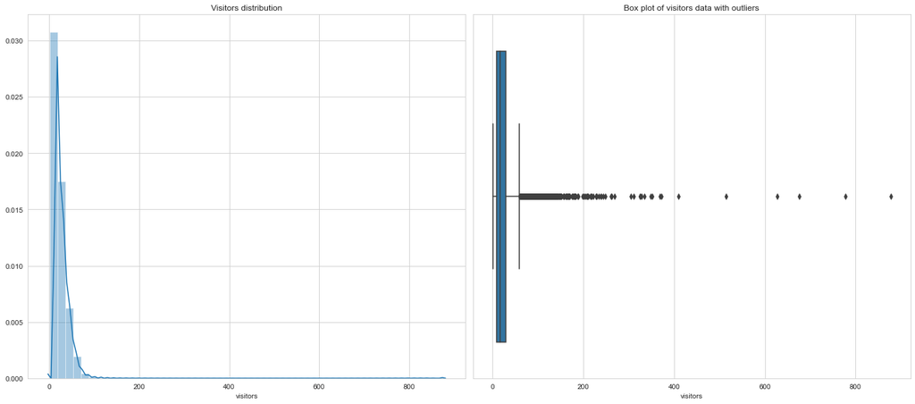

```python
fig = plt.figure(figsize=(18, 8))

ax1 = fig.add_subplot(121)

sns.distplot(train_data.visitors, ax=ax1)
plt.title("Visitors distribution")

ax2 = fig.add_subplot(122)

sns.boxplot(train_data.visitors, ax=ax2)
plt.title("Box plot of visitors data with outliers")

plt.tight_layout()
plt.show()
```

```python
# remove the outliers > Q3 + 1.5*IQR

def calulate_IQR_outlier_range(data):

    q1, q3 = np.quantile(data.values, [0.25, 0.75])
    lower_IQR = q1 - (1.5 * (q3 - q1))
    higher_IQR = q3 + (1.5 * (q3 - q1))

    return lower_IQR, higher_IQR


visitors_lower, visitors_higher = calulate_IQR_outlier_range(train_data.visitors)

train_data = train_data[train_data.visitors < visitors_higher]
```

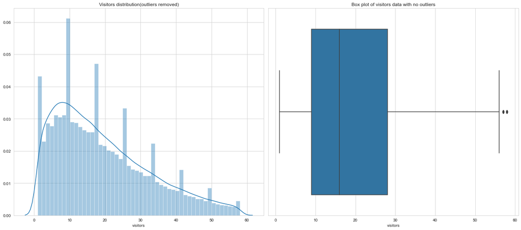

```python
fig = plt.figure(figsize=(18, 8))

ax1 = fig.add_subplot(121)

sns.distplot(train_data.visitors, ax=ax1)
plt.title("Visitors distribution(outliers removed)")

ax2 = fig.add_subplot(122)

sns.boxplot(train_data.visitors, ax=ax2)
plt.title("Box plot of visitors data with no outliers")

plt.tight_layout()
plt.show()
```

- **The above distribution is skewed as most of restaurnts have visitors within 20 on average**
- **we will use log transform to make it weakly stationary or weakly gaussian**

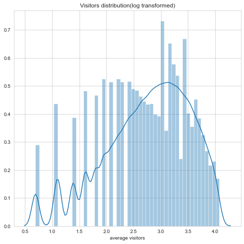

```python
fig = plt.figure(figsize=(18, 8))

ax1 = fig.add_subplot(121)

sns.distplot(np.log1p(train_data.visitors), ax=ax1)
plt.title("Visitors distribution(log transformed)")
plt.xlabel("average visitors")
plt.show()
```

#### area wise restaurant count

- area wise restaurant count can be seen as a competition in the area

```python
temp = train_data.groupby('air_area_name').air_store_id.count()
train_data = pd.merge(train_data, temp, how='left', on='air_area_name')
train_data.rename(columns={'air_store_id_x': 'air_store_id', 'air_store_id_y': 'area_competition'}, inplace=True)
```

```python
train_data.head(3)
```

|  | air_store_id | visit_date | visitors | day_of_week | holiday_flg | air_genre_name | air_area_name | latitude | longitude | reserve_visitors_air | reservation_gap | reserve_visitors_hpg | hpg_reserve_gap | area_competition |
| --- | --- | --- | --- | --- | --- | --- | --- | --- | --- | --- | --- | --- | --- | --- |
| 0 | air_fab092c35776a9b1 | 2016-01-01 | 19 | Friday | 1 | Cafe/Sweets | Fukuoka-ken Fukuoka-shi Momochi | 33.581941 | 130.348436 | 0.0 | 0.0 | 0.0 | 0.0 | 1914 |
| 1 | air_39dccf7df20b1c6a | 2016-01-01 | 55 | Friday | 1 | Izakaya | Hyōgo-ken Takarazuka-shi Tōyōchō | 34.799767 | 135.360073 | 0.0 | 0.0 | 0.0 | 0.0 | 1414 |
| 2 | air_79f528087f49df06 | 2016-01-01 | 42 | Friday | 1 | Western food | Tōkyō-to Suginami-ku Asagayaminami | 35.699566 | 139.636438 | 0.0 | 0.0 | 0.0 | 0.0 | 6808 |

#### area wise same genre restaurant count

- area wise same genre restaurant count can be seen as a competition in the area among same genre

```python
temp = train_data.groupby(['air_area_name', 'air_genre_name'], as_index=False).air_store_id.count()
train_data = pd.merge(train_data, temp, how='left', on=['air_area_name', 'air_genre_name'])
train_data.rename(columns={'air_store_id_x': 'air_store_id', 'air_store_id_y': 'area_genre_competition'}, inplace=True)
```

```python
train_data.head(2)
```

|  | air_store_id | visit_date | visitors | day_of_week | holiday_flg | air_genre_name | air_area_name | latitude | longitude | reserve_visitors_air | reservation_gap | reserve_visitors_hpg | hpg_reserve_gap | area_competition | area_genre_competition |
| --- | --- | --- | --- | --- | --- | --- | --- | --- | --- | --- | --- | --- | --- | --- | --- |
| 0 | air_fab092c35776a9b1 | 2016-01-01 | 19 | Friday | 1 | Cafe/Sweets | Fukuoka-ken Fukuoka-shi Momochi | 33.581941 | 130.348436 | 0.0 | 0.0 | 0.0 | 0.0 | 1914 | 1439 |
| 1 | air_39dccf7df20b1c6a | 2016-01-01 | 55 | Friday | 1 | Izakaya | Hyōgo-ken Takarazuka-shi Tōyōchō | 34.799767 | 135.360073 | 0.0 | 0.0 | 0.0 | 0.0 | 1414 | 934 |

#### reservation gap visitor features

```python
# get the reservations done on HPG
hpg_reserve = pd.merge(store_id_relation, hpg_reservation_data, how='left', on='hpg_store_id')
hpg_reserve.drop("hpg_store_id", axis=1, inplace=True)

# concat both AIR and HPG reservations
reservation_data = pd.concat([air_reservation_data, hpg_reserve])

# add the hour gap diff between reseravtion time as a feature
reservation_data.visit_datetime = pd.to_datetime(reservation_data.visit_datetime)
reservation_data.reserve_datetime = pd.to_datetime(reservation_data.reserve_datetime)
reservation_data['reservation_gap'] = reservation_data.visit_datetime - reservation_data.reserve_datetime
reservation_data['reservation_gap'] = reservation_data.reservation_gap / np.timedelta64(1,'h')


# encode the visitors based on the reservation gap
# 6th place solutuon features
# if reservation gap is under 12 hr
reservation_data['reserve_visitor_lt_12hr'] = np.where(reservation_data.reservation_gap < 12, reservation_data.reserve_visitors, 0)

# if reservation gap is between 12-36 hr
reservation_data['reserve_visitor_bt_12_36'] = np.where((reservation_data.reservation_gap >= 12) & (reservation_data.reservation_gap < 36),
                                                        reservation_data.reserve_visitors, 0)

# if reservation gap is between 37-59 hr
reservation_data['reserve_visitor_bt_36_59'] = np.where((reservation_data.reservation_gap >= 36) & (reservation_data.reservation_gap < 59),
                                                        reservation_data.reserve_visitors, 0)

# if reservation gap is between 59-85 hr
reservation_data['reserve_visitor_bt_59_85'] = np.where((reservation_data.reservation_gap >= 59) & (reservation_data.reservation_gap < 85),
                                                        reservation_data.reserve_visitors, 0)

# if reservation gap is greater 85 hr
reservation_data['reserve_visitor_gt_85'] = np.where(reservation_data.reservation_gap >= 85, reservation_data.reserve_visitors, 0)
reservation_data['visit_date'] = reservation_data.visit_datetime.dt.date

# group by per store on visit date = reservation visitors
reservation_features = reservation_data.groupby(['air_store_id', 'visit_date'], as_index=False)[['reserve_visitors', 'reserve_visitor_lt_12hr',
                                                                                                'reserve_visitor_bt_12_36', 'reserve_visitor_bt_36_59',
                                                                                                'reserve_visitor_bt_59_85', 'reserve_visitor_gt_85']].sum()


# merge the reservation features with train data per store on visit date
train_data.drop(['reserve_visitors_air', 'reserve_visitors_hpg', 'reservation_gap', 'hpg_reserve_gap'], axis=1, inplace=True)
reservation_features.visit_date = pd.to_datetime(reservation_features.visit_date)
train_data = pd.merge(train_data, reservation_features, how='left', on=['air_store_id', 'visit_date'])
train_data.fillna(0, inplace=True)
train_data.head()
```

|  | air_store_id | visit_date | visitors | day_of_week | holiday_flg | air_genre_name | air_area_name | latitude | longitude | area_competition | area_genre_competition | reserve_visitors | reserve_visitor_lt_12hr | reserve_visitor_bt_12_36 | reserve_visitor_bt_36_59 | reserve_visitor_bt_59_85 | reserve_visitor_gt_85 |
| --- | --- | --- | --- | --- | --- | --- | --- | --- | --- | --- | --- | --- | --- | --- | --- | --- | --- |
| 0 | air_fab092c35776a9b1 | 2016-01-01 | 19 | Friday | 1 | Cafe/Sweets | Fukuoka-ken Fukuoka-shi Momochi | 33.581941 | 130.348436 | 1914 | 1439 | 0.0 | 0.0 | 0.0 | 0.0 | 0.0 | 0.0 |
| 1 | air_39dccf7df20b1c6a | 2016-01-01 | 55 | Friday | 1 | Izakaya | Hyōgo-ken Takarazuka-shi Tōyōchō | 34.799767 | 135.360073 | 1414 | 934 | 0.0 | 0.0 | 0.0 | 0.0 | 0.0 | 0.0 |
| 2 | air_79f528087f49df06 | 2016-01-01 | 42 | Friday | 1 | Western food | Tōkyō-to Suginami-ku Asagayaminami | 35.699566 | 139.636438 | 6808 | 1052 | 0.0 | 0.0 | 0.0 | 0.0 | 0.0 | 0.0 |
| 3 | air_08ba8cd01b3ba010 | 2016-01-01 | 11 | Friday | 1 | Izakaya | Miyagi-ken Sendai-shi Kamisugi | 38.269076 | 140.870403 | 5836 | 2909 | 0.0 | 0.0 | 0.0 | 0.0 | 0.0 | 0.0 |
| 4 | air_81c5dff692063446 | 2016-01-01 | 7 | Friday | 1 | Dining bar | Ōsaka-fu Ōsaka-shi Ōgimachi | 34.705362 | 135.510025 | 7432 | 2247 | 0.0 | 0.0 | 0.0 | 0.0 | 0.0 | 0.0 |

```python
# log transform the reservation featues
reservation_columns = reservation_features.columns[2:]
for column in reservation_columns:
    train_data[column] = train_data[column].apply(lambda a: np.log1p(a))

train_data.head()
```

|  | air_store_id | visit_date | visitors | day_of_week | holiday_flg | air_genre_name | air_area_name | latitude | longitude | area_competition | area_genre_competition | reserve_visitors | reserve_visitor_lt_12hr | reserve_visitor_bt_12_36 | reserve_visitor_bt_36_59 | reserve_visitor_bt_59_85 | reserve_visitor_gt_85 |
| --- | --- | --- | --- | --- | --- | --- | --- | --- | --- | --- | --- | --- | --- | --- | --- | --- | --- |
| 0 | air_fab092c35776a9b1 | 2016-01-01 | 19 | Friday | 1 | Cafe/Sweets | Fukuoka-ken Fukuoka-shi Momochi | 33.581941 | 130.348436 | 1914 | 1439 | 0.0 | 0.0 | 0.0 | 0.0 | 0.0 | 0.0 |
| 1 | air_39dccf7df20b1c6a | 2016-01-01 | 55 | Friday | 1 | Izakaya | Hyōgo-ken Takarazuka-shi Tōyōchō | 34.799767 | 135.360073 | 1414 | 934 | 0.0 | 0.0 | 0.0 | 0.0 | 0.0 | 0.0 |
| 2 | air_79f528087f49df06 | 2016-01-01 | 42 | Friday | 1 | Western food | Tōkyō-to Suginami-ku Asagayaminami | 35.699566 | 139.636438 | 6808 | 1052 | 0.0 | 0.0 | 0.0 | 0.0 | 0.0 | 0.0 |
| 3 | air_08ba8cd01b3ba010 | 2016-01-01 | 11 | Friday | 1 | Izakaya | Miyagi-ken Sendai-shi Kamisugi | 38.269076 | 140.870403 | 5836 | 2909 | 0.0 | 0.0 | 0.0 | 0.0 | 0.0 | 0.0 |
| 4 | air_81c5dff692063446 | 2016-01-01 | 7 | Friday | 1 | Dining bar | Ōsaka-fu Ōsaka-shi Ōgimachi | 34.705362 | 135.510025 | 7432 | 2247 | 0.0 | 0.0 | 0.0 | 0.0 | 0.0 | 0.0 |

#### Basic statistics features on visitors

```python
# log transform the visitors variable:
train_data.visitors = train_data.visitors.apply(lambda x: np.log1p(x))

# average visitors per store on holiday, weekends, and working
# if day is working then 1,  else 0
train_data['working'] = np.where((train_data.holiday_flg == 0) & (train_data.day_of_week.isin(['Monday', 'Tuesday', 'Wednesday', 'Thursday', 'Friday'])), 1, 0)

# mean visitor to the restaurant based on day and if its working
mean_visitor_working = train_data.groupby(['air_store_id', 'day_of_week', 'working'], as_index=False).visitors.mean()
train_data = pd.merge(train_data, mean_visitor_working, how='left', on=['air_store_id', 'day_of_week', 'working'])
train_data.rename(columns={'visitors_x': 'visitors', 'visitors_y': 'mean_visitors'}, inplace=True)

# Median visitor to the restaurant based on day and if its working
median_visitor_working = train_data.groupby(['air_store_id', 'day_of_week', 'working'], as_index=False).visitors.median()
train_data = pd.merge(train_data, median_visitor_working, how='left', on=['air_store_id', 'day_of_week', 'working'])
train_data.rename(columns={'visitors_x': 'visitors', 'visitors_y': 'median_visitors'}, inplace=True)

# minimum visitors on restaurant based on day and if its working
min_visitor_working = train_data.groupby(['air_store_id', 'day_of_week', 'working'], as_index=False).visitors.min()
train_data = pd.merge(train_data, min_visitor_working, how='left', on=['air_store_id', 'day_of_week', 'working'])
train_data.rename(columns={'visitors_x': 'visitors', 'visitors_y': 'min_visitors'}, inplace=True)

# maximum visitors on restaurant based on day and if its working
max_visitor_working = train_data.groupby(['air_store_id', 'day_of_week', 'working'], as_index=False).visitors.max()
train_data = pd.merge(train_data, max_visitor_working, how='left', on=['air_store_id', 'day_of_week', 'working'])
train_data.rename(columns={'visitors_x': 'visitors', 'visitors_y': 'max_visitors'}, inplace=True)
```

```python
train_data.head(2)
```

|  | air_store_id | visit_date | visitors | day_of_week | holiday_flg | air_genre_name | air_area_name | latitude | longitude | area_competition | ... | reserve_visitor_lt_12hr | reserve_visitor_bt_12_36 | reserve_visitor_bt_36_59 | reserve_visitor_bt_59_85 | reserve_visitor_gt_85 | working | mean_visitors | median_visitors | min_visitors | max_visitors |
| --- | --- | --- | --- | --- | --- | --- | --- | --- | --- | --- | --- | --- | --- | --- | --- | --- | --- | --- | --- | --- | --- |
| 0 | air_fab092c35776a9b1 | 2016-01-01 | 2.995732 | Friday | 1 | Cafe/Sweets | Fukuoka-ken Fukuoka-shi Momochi | 33.581941 | 130.348436 | 1914 | ... | 0.0 | 0.0 | 0.0 | 0.0 | 0.0 | 0 | 2.824438 | 2.884160 | 2.484907 | 3.044522 |
| 1 | air_39dccf7df20b1c6a | 2016-01-01 | 4.025352 | Friday | 1 | Izakaya | Hyōgo-ken Takarazuka-shi Tōyōchō | 34.799767 | 135.360073 | 1414 | ... | 0.0 | 0.0 | 0.0 | 0.0 | 0.0 | 0 | 3.258088 | 3.352207 | 2.302585 | 4.025352 |

2 rows × 22 columns

#### expected visitors based on the genre in the area

```python
# get total visitors in the area per genre
area_genre_total_visitors = train_data.groupby(['air_area_name', 'air_genre_name'], as_index=False).visitors.sum()
train_data = pd.merge(train_data, area_genre_total_visitors, how='left', on=['air_area_name', 'air_genre_name'])
train_data.rename(columns={'visitors_x': 'visitors', 'visitors_y': 'total_area_genre_visitors'}, inplace=True)

# expected visitors in the area of a genre
train_data['area_genre_expected_visitors'] = train_data.total_area_genre_visitors / train_data.area_genre_competition
train_data.drop('total_area_genre_visitors', axis=1, inplace=True)
train_data.head()
```

|  | air_store_id | visit_date | visitors | day_of_week | holiday_flg | air_genre_name | air_area_name | latitude | longitude | area_competition | ... | reserve_visitor_bt_12_36 | reserve_visitor_bt_36_59 | reserve_visitor_bt_59_85 | reserve_visitor_gt_85 | working | mean_visitors | median_visitors | min_visitors | max_visitors | area_genre_expected_visitors |
| --- | --- | --- | --- | --- | --- | --- | --- | --- | --- | --- | --- | --- | --- | --- | --- | --- | --- | --- | --- | --- | --- |
| 0 | air_fab092c35776a9b1 | 2016-01-01 | 2.995732 | Friday | 1 | Cafe/Sweets | Fukuoka-ken Fukuoka-shi Momochi | 33.581941 | 130.348436 | 1914 | ... | 0.0 | 0.0 | 0.0 | 0.0 | 0 | 2.824438 | 2.884160 | 2.484907 | 3.044522 | 2.496051 |
| 1 | air_39dccf7df20b1c6a | 2016-01-01 | 4.025352 | Friday | 1 | Izakaya | Hyōgo-ken Takarazuka-shi Tōyōchō | 34.799767 | 135.360073 | 1414 | ... | 0.0 | 0.0 | 0.0 | 0.0 | 0 | 3.258088 | 3.352207 | 2.302585 | 4.025352 | 3.195417 |
| 2 | air_79f528087f49df06 | 2016-01-01 | 3.761200 | Friday | 1 | Western food | Tōkyō-to Suginami-ku Asagayaminami | 35.699566 | 139.636438 | 6808 | ... | 0.0 | 0.0 | 0.0 | 0.0 | 0 | 3.585655 | 3.663562 | 3.332205 | 3.761200 | 2.618750 |
| 3 | air_08ba8cd01b3ba010 | 2016-01-01 | 2.484907 | Friday | 1 | Izakaya | Miyagi-ken Sendai-shi Kamisugi | 38.269076 | 140.870403 | 5836 | ... | 0.0 | 0.0 | 0.0 | 0.0 | 0 | 2.795438 | 2.802901 | 2.484907 | 3.091042 | 2.931669 |
| 4 | air_81c5dff692063446 | 2016-01-01 | 2.079442 | Friday | 1 | Dining bar | Ōsaka-fu Ōsaka-shi Ōgimachi | 34.705362 | 135.510025 | 7432 | ... | 0.0 | 0.0 | 0.0 | 0.0 | 0 | 2.892761 | 2.954041 | 2.079442 | 3.583519 | 2.623756 |

5 rows × 23 columns

#### expected visitors based on the area

```python
# get total visitors in the area
area_total_visitors = train_data.groupby(['air_area_name'], as_index=False).visitors.sum()
train_data = pd.merge(train_data, area_total_visitors, how='left', on=['air_area_name'])
train_data.rename(columns={'visitors_x': 'visitors', 'visitors_y': 'total_area_visitors'}, inplace=True)

# expected visitors in the area
train_data['area_expected_visitors'] = train_data.total_area_visitors / train_data.area_competition
train_data.drop('total_area_visitors', axis=1, inplace=True)
train_data.head(3)
```

|  | air_store_id | visit_date | visitors | day_of_week | holiday_flg | air_genre_name | air_area_name | latitude | longitude | area_competition | ... | reserve_visitor_bt_36_59 | reserve_visitor_bt_59_85 | reserve_visitor_gt_85 | working | mean_visitors | median_visitors | min_visitors | max_visitors | area_genre_expected_visitors | area_expected_visitors |
| --- | --- | --- | --- | --- | --- | --- | --- | --- | --- | --- | --- | --- | --- | --- | --- | --- | --- | --- | --- | --- | --- |
| 0 | air_fab092c35776a9b1 | 2016-01-01 | 2.995732 | Friday | 1 | Cafe/Sweets | Fukuoka-ken Fukuoka-shi Momochi | 33.581941 | 130.348436 | 1914 | ... | 0.0 | 0.0 | 0.0 | 0 | 2.824438 | 2.884160 | 2.484907 | 3.044522 | 2.496051 | 2.585441 |
| 1 | air_39dccf7df20b1c6a | 2016-01-01 | 4.025352 | Friday | 1 | Izakaya | Hyōgo-ken Takarazuka-shi Tōyōchō | 34.799767 | 135.360073 | 1414 | ... | 0.0 | 0.0 | 0.0 | 0 | 3.258088 | 3.352207 | 2.302585 | 4.025352 | 3.195417 | 3.061228 |
| 2 | air_79f528087f49df06 | 2016-01-01 | 3.761200 | Friday | 1 | Western food | Tōkyō-to Suginami-ku Asagayaminami | 35.699566 | 139.636438 | 6808 | ... | 0.0 | 0.0 | 0.0 | 0 | 3.585655 | 3.663562 | 3.332205 | 3.761200 | 2.618750 | 2.666738 |

3 rows × 24 columns

#### Date features

```python
train_data['year'] = train_data.visit_date.dt.year
train_data['month'] = train_data.visit_date.dt.month
train_data['day_of_month'] = train_data.visit_date.dt.day
```

```python
train_data.head(2)
```

[output not shown]

2 rows × 27 columns

#### No. of reservations on the visit date

```python
reservation_count_feature = reservation_data.groupby(['air_store_id', 'visit_date'], as_index=False).visit_datetime.count()
reservation_count_feature.visit_date = pd.to_datetime(reservation_count_feature.visit_date)
train_data = pd.merge(train_data, reservation_count_feature, how='left', on=['air_store_id', 'visit_date'])
train_data.rename(columns={'visit_datetime': 'reservation_count'}, inplace=True)
train_data.fillna(0, inplace=True)
```

```python
train_data.head(2)
```

[output not shown]

2 rows × 28 columns

#### prefecture: Japan has 47 prefectures (hierarchy in area names)

```python
#prefecture
train_data['area_prefecture'] = [area.split()[0] for area in train_data['air_area_name'].values]

# sub prefecture
train_data['area_sub_pref'] = [area.split()[1] for area in train_data['air_area_name'].values]

train_data.head()
```

|  | air_store_id | visit_date | visitors | day_of_week | holiday_flg | air_genre_name | air_area_name | latitude | longitude | area_competition | ... | median_visitors | min_visitors | max_visitors | area_genre_expected_visitors | area_expected_visitors | year | month | day_of_month | area_prefecture | area_sub_pref |
| --- | --- | --- | --- | --- | --- | --- | --- | --- | --- | --- | --- | --- | --- | --- | --- | --- | --- | --- | --- | --- | --- |
| 0 | air_fab092c35776a9b1 | 2016-01-01 | 2.995732 | Friday | 1 | Cafe/Sweets | Fukuoka-ken Fukuoka-shi Momochi | 33.581941 | 130.348436 | 1914 | ... | 2.884160 | 2.484907 | 3.044522 | 2.496051 | 2.585441 | 2016 | 1 | 1 | Fukuoka-ken | Fukuoka-shi |
| 1 | air_39dccf7df20b1c6a | 2016-01-01 | 4.025352 | Friday | 1 | Izakaya | Hyōgo-ken Takarazuka-shi Tōyōchō | 34.799767 | 135.360073 | 1414 | ... | 3.352207 | 2.302585 | 4.025352 | 3.195417 | 3.061228 | 2016 | 1 | 1 | Hyōgo-ken | Takarazuka-shi |
| 2 | air_79f528087f49df06 | 2016-01-01 | 3.761200 | Friday | 1 | Western food | Tōkyō-to Suginami-ku Asagayaminami | 35.699566 | 139.636438 | 6808 | ... | 3.663562 | 3.332205 | 3.761200 | 2.618750 | 2.666738 | 2016 | 1 | 1 | Tōkyō-to | Suginami-ku |
| 3 | air_08ba8cd01b3ba010 | 2016-01-01 | 2.484907 | Friday | 1 | Izakaya | Miyagi-ken Sendai-shi Kamisugi | 38.269076 | 140.870403 | 5836 | ... | 2.802901 | 2.484907 | 3.091042 | 2.931669 | 2.785064 | 2016 | 1 | 1 | Miyagi-ken | Sendai-shi |
| 4 | air_81c5dff692063446 | 2016-01-01 | 2.079442 | Friday | 1 | Dining bar | Ōsaka-fu Ōsaka-shi Ōgimachi | 34.705362 | 135.510025 | 7432 | ... | 2.954041 | 2.079442 | 3.583519 | 2.623756 | 2.741986 | 2016 | 1 | 1 | Ōsaka-fu | Ōsaka-shi |

5 rows × 29 columns

#### window statistics features: restaurant wise monthly visitors

```python
# get the month wise mean visitors to restaurant
temp = train_data.groupby(['air_store_id', 'month'], as_index=False).visitors.mean()
train_data = pd.merge(train_data, temp, how='left', on=['air_store_id', 'month'])
train_data.rename(columns={'visitors_x': 'visitors', 'visitors_y': 'monthly_mean_visitors'}, inplace=True)

# get the month wise median visitors to restaurant
temp = train_data.groupby(['air_store_id', 'month'], as_index=False).visitors.median()
train_data = pd.merge(train_data, temp, how='left', on=['air_store_id', 'month'])
train_data.rename(columns={'visitors_x': 'visitors', 'visitors_y': 'monthly_median_visitor'}, inplace=True)

# get the month wise min visitors to restaurant
temp = train_data.groupby(['air_store_id', 'month'], as_index=False).visitors.min()
train_data = pd.merge(train_data, temp, how='left', on=['air_store_id', 'month'])
train_data.rename(columns={'visitors_x': 'visitors', 'visitors_y': 'monthly_minimum_visitor'}, inplace=True)

# get the month wise max visitors to restaurant
temp = train_data.groupby(['air_store_id', 'month'], as_index=False).visitors.max()
train_data = pd.merge(train_data, temp, how='left', on=['air_store_id', 'month'])
train_data.rename(columns={'visitors_x': 'visitors', 'visitors_y': 'monthly_max_visitor'}, inplace=True)
```

#### window statistics features: restaurant genre wise monthly statistics

```python
# get the month wise mean visitors per genre
temp = train_data.groupby(['air_genre_name', 'month'], as_index=False).visitors.mean()
train_data = pd.merge(train_data, temp, how='left', on=['air_genre_name', 'month'])
train_data.rename(columns={'visitors_x': 'visitors', 'visitors_y': 'monthly_genre_mean_visitors'}, inplace=True)

# get the month wise median visitors per genre
temp = train_data.groupby(['air_genre_name', 'month'], as_index=False).visitors.median()
train_data = pd.merge(train_data, temp, how='left', on=['air_genre_name', 'month'])
train_data.rename(columns={'visitors_x': 'visitors', 'visitors_y': 'monthly_genre_median_visitor'}, inplace=True)

# get the month wise min visitors per genre
temp = train_data.groupby(['air_genre_name', 'month'], as_index=False).visitors.min()
train_data = pd.merge(train_data, temp, how='left', on=['air_genre_name', 'month'])
train_data.rename(columns={'visitors_x': 'visitors', 'visitors_y': 'monthly_genre_minimum_visitor'}, inplace=True)

# get the month wise max visitors per genre
temp = train_data.groupby(['air_genre_name', 'month'], as_index=False).visitors.max()
train_data = pd.merge(train_data, temp, how='left', on=['air_genre_name', 'month'])
train_data.rename(columns={'visitors_x': 'visitors', 'visitors_y': 'monthly_genre_max_visitor'}, inplace=True)
```

#### weather data for the restaurants:

- The local weather has also affect on the number of visitors, Hence we will get the local japanese weather stations data for the restaurants from [Weather Data for Recruit Restaurant Competition](https://www.kaggle.com/huntermcgushion/rrv-weather-data)
- we will use the temperature and precipatation, since the rest contain nan values exceedingly

```python
# read weather data
weather_data = os.path.join(data_path, "weather_data")
weather_station_data = os.path.join(weather_data, "1-1-16_5-31-17_Weather")

# check if processed file exists
if not os.path.isfile(processed_data_path + "/processed_air_store_weather_info.csv"):

    # prepare weather_data
    air_store_near_station = pd.read_csv(weather_data + "/air_store_info_with_nearest_active_station.csv")
    air_store_near_station = air_store_near_station.loc[:,['air_store_id', 'station_id']]
    air_store_near_station = air_store_near_station.set_index('air_store_id')

    # fetch weather data from each station for air_store
    air_store_weather_info = pd.DataFrame(columns=['calendar_date', 'avg_temperature',
                                                        'low_temperature', 'high_temperature',
                                                        'precipitation'])
    for index, row in air_store_near_station.iterrows():
        weather_file = os.path.join(weather_station_data, row.station_id + ".csv")
        temp_weather = pd.read_csv(weather_file).loc[:, ['calendar_date', 'avg_temperature',
                                                        'low_temperature', 'high_temperature',
                                                        'precipitation']]
        temp_weather.fillna(0, inplace=True)
        temp_weather['air_store_id'] = index

        air_store_weather_info = pd.concat([air_store_weather_info, temp_weather])

    # rearrage the columns
    air_store_weather_info = air_store_weather_info.loc[:,['air_store_id','calendar_date', 'avg_temperature',
                                                        'low_temperature', 'high_temperature',
                                                        'precipitation']].reset_index(drop=True)
    # save the processed file
    air_store_weather_info.to_csv(processed_data_path + "/processed_air_store_weather_info.csv", index=False)
else:

    air_store_weather_info = pd.read_csv(processed_data_path + "/processed_air_store_weather_info.csv")
```

```python
air_store_weather_info.calendar_date = pd.to_datetime(air_store_weather_info.calendar_date)
air_store_weather_info.rename(columns={'calendar_date': 'visit_date'}, inplace=True)
train_data = pd.merge(train_data, air_store_weather_info, how='left', on=['air_store_id', 'visit_date'])
```

```python
train_data.head()
```

|  | air_store_id | visit_date | visitors | day_of_week | holiday_flg | air_genre_name | air_area_name | latitude | longitude | area_competition | ... | monthly_minimum_visitor | monthly_max_visitor | monthly_genre_mean_visitors | monthly_genre_median_visitor | monthly_genre_minimum_visitor | monthly_genre_max_visitor | avg_temperature | low_temperature | high_temperature | precipitation |
| --- | --- | --- | --- | --- | --- | --- | --- | --- | --- | --- | --- | --- | --- | --- | --- | --- | --- | --- | --- | --- | --- |
| 0 | air_fab092c35776a9b1 | 2016-01-01 | 2.995732 | Friday | 1 | Cafe/Sweets | Fukuoka-ken Fukuoka-shi Momochi | 33.581941 | 130.348436 | 1914 | ... | 0.693147 | 2.995732 | 2.784519 | 2.890372 | 0.693147 | 4.077537 | 7.3 | 3.1 | 12.6 | 0.0 |
| 1 | air_39dccf7df20b1c6a | 2016-01-01 | 4.025352 | Friday | 1 | Izakaya | Hyōgo-ken Takarazuka-shi Tōyōchō | 34.799767 | 135.360073 | 1414 | ... | 0.693147 | 4.025352 | 2.843321 | 2.944439 | 0.693147 | 4.077537 | 0.0 | 0.0 | 0.0 | 0.0 |
| 2 | air_79f528087f49df06 | 2016-01-01 | 3.761200 | Friday | 1 | Western food | Tōkyō-to Suginami-ku Asagayaminami | 35.699566 | 139.636438 | 6808 | ... | 0.693147 | 4.060443 | 2.814051 | 2.944439 | 0.693147 | 4.077537 | 6.9 | 2.1 | 11.8 | 0.0 |
| 3 | air_08ba8cd01b3ba010 | 2016-01-01 | 2.484907 | Friday | 1 | Izakaya | Miyagi-ken Sendai-shi Kamisugi | 38.269076 | 140.870403 | 5836 | ... | 0.693147 | 3.178054 | 2.843321 | 2.944439 | 0.693147 | 4.077537 | 2.4 | -1.5 | 6.1 | 0.0 |
| 4 | air_81c5dff692063446 | 2016-01-01 | 2.079442 | Friday | 1 | Dining bar | Ōsaka-fu Ōsaka-shi Ōgimachi | 34.705362 | 135.510025 | 7432 | ... | 0.693147 | 3.970292 | 2.565440 | 2.639057 | 0.693147 | 4.077537 | 7.6 | 4.4 | 11.4 | 0.0 |

5 rows × 41 columns

```python
train_data.to_csv(processed_data_path + "/train_data_FE_v1.csv", index=False)
```